# 007

## Описание проекта:

**Контекст**  
Вы — аналитик крупного интернет-магазина. Вместе с отделом маркетинга вы подготовили список гипотез для увеличения выручки. Приоритизируйте гипотезы, запустите A/B-тест и проанализируйте результаты.

### Часть 1. Приоритизация гипотез.

**Задача**

- Примените фреймворк ICE для приоритизации гипотез. Отсортируйте их по убыванию приоритета.
- Примените фреймворк RICE для приоритизации гипотез. Отсортируйте их по убыванию приоритета.
- Укажите, как изменилась приоритизация гипотез при применении RICE вместо ICE. Объясните, почему так произошло.

### Часть 2. Анализ A/B-теста

Вы провели A/B-тест и получили результаты, которые описаны в файлах /datasets/orders.csv и /datasets/visitors.csv.

**Задача**  
Проанализируйте A/B-тест:

- Постройте график кумулятивной выручки по группам. Сделайте выводы и предположения.
- Постройте график кумулятивного среднего чека по группам. Сделайте выводы и предположения.
- Постройте график относительного изменения кумулятивного среднего чека группы B к группе A. Сделайте выводы и предположения.
- Постройте график кумулятивной конверсии по группам. Сделайте выводы и предположения.
- Постройте график относительного изменения кумулятивной конверсии группы B к группе A. Сделайте выводы и предположения.
- Постройте точечный график количества заказов по пользователям. Сделайте выводы и предположения.
- Посчитайте 95-й и 99-й перцентили количества заказов на пользователя. Выберите границу для определения аномальных пользователей.
- Постройте точечный график стоимостей заказов. Сделайте выводы и предположения.
- Посчитайте 95-й и 99-й перцентили стоимости заказов. Выберите границу для определения аномальных заказов.
- Посчитайте статистическую значимость различий в конверсии между группами по «сырым» данным. Сделайте выводы и предположения.
- Посчитайте статистическую значимость различий в среднем чеке заказа между группами по «сырым» данным. Сделайте выводы и предположения.
- Посчитайте статистическую значимость различий в конверсии между группами по «очищенным» данным. Сделайте выводы и предположения.
- Посчитайте статистическую значимость различий в среднем чеке заказа между группами по «очищенным» данным. Сделайте выводы и предположения.
- Примите решение по результатам теста и объясните его. Варианты решений:
  1. Остановить тест, зафиксировать победу одной из групп.
  2. Остановить тест, зафиксировать отсутствие различий между группами.
  3. Продолжить тест.

### Описание данных

**Данные для первой части**

Файл /datasets/hypothesis.csv

- Hypothesis — краткое описание гипотезы;
- Reach — охват пользователей по 10-балльной шкале;
- Impact — влияние на пользователей по 10-балльной шкале;
- Confidence — уверенность в гипотезе по 10-балльной шкале;
- Efforts — затраты ресурсов на проверку гипотезы по 10-балльной шкале. Чем больше значение Efforts, тем дороже проверка гипотезы.

**Данные для второй части**

Файл /datasets/orders.csv

- transactionId — идентификатор заказа;
- visitorId — идентификатор пользователя, совершившего заказ;
- date — дата, когда был совершён заказ;
- revenue — выручка заказа;
- group — группа A/B-теста, в которую попал заказ.

Файл /datasets/visitors.csv

- date — дата;
- group — группа A/B-теста;
- visitors — количество пользователей в указанную дату в указанной группе A/B-теста

# Содержание

## Загрузка и подготовка данных

```python
import pandas as pd
from matplotlib import pyplot as plt
import datetime as dt
import scipy.stats as stats
import numpy as np
pd.set_option('display.max_colwidth', None)
pd.set_option('display.float_format', '{:.2f}'.format)
```

```python
try:
    hypothesis = pd.read_csv('/datasets/hypothesis.csv')
    orders = pd.read_csv('/datasets/orders.csv')
    visitors = pd.read_csv('/datasets/visitors.csv')
except:
    print('Ошибка подгрузки данных')
```

### Таблица hypothesis

```python
hypothesis.info()
hypothesis
```

```
<class 'pandas.core.frame.DataFrame'>
RangeIndex: 9 entries, 0 to 8
Data columns (total 5 columns):
 #   Column      Non-Null Count  Dtype
---  ------      --------------  -----
 0   Hypothesis  9 non-null      object
 1   Reach       9 non-null      int64
 2   Impact      9 non-null      int64
 3   Confidence  9 non-null      int64
 4   Efforts     9 non-null      int64
dtypes: int64(4), object(1)
memory usage: 488.0+ bytes
```

|  | Hypothesis | Reach | Impact | Confidence | Efforts |
| --- | --- | --- | --- | --- | --- |
| 0 | Добавить два новых канала привлечения трафика, что позволит привлекать на 30% больше пользователей | 3 | 10 | 8 | 6 |
| 1 | Запустить собственную службу доставки, что сократит срок доставки заказов | 2 | 5 | 4 | 10 |
| 2 | Добавить блоки рекомендаций товаров на сайт интернет магазина, чтобы повысить конверсию и средний чек заказа | 8 | 3 | 7 | 3 |
| 3 | Изменить структура категорий, что увеличит конверсию, т.к. пользователи быстрее найдут нужный товар | 8 | 3 | 3 | 8 |
| 4 | Изменить цвет фона главной страницы, чтобы увеличить вовлеченность пользователей | 3 | 1 | 1 | 1 |
| 5 | Добавить страницу отзывов клиентов о магазине, что позволит увеличить количество заказов | 3 | 2 | 2 | 3 |
| 6 | Показать на главной странице баннеры с актуальными акциями и распродажами, чтобы увеличить конверсию | 5 | 3 | 8 | 3 |
| 7 | Добавить форму подписки на все основные страницы, чтобы собрать базу клиентов для email-рассылок | 10 | 7 | 8 | 5 |
| 8 | Запустить акцию, дающую скидку на товар в день рождения | 1 | 9 | 9 | 5 |

Приведем к нижнему регистру названия столбцов

```python
hypothesis.columns = hypothesis.columns.str.lower()
hypothesis.columns
```

```
Index(['hypothesis', 'reach', 'impact', 'confidence', 'efforts'], dtype='object')
```

### Таблица orders

```python
orders.info()
orders.sample(5)
```

```
<class 'pandas.core.frame.DataFrame'>
RangeIndex: 1197 entries, 0 to 1196
Data columns (total 5 columns):
 #   Column         Non-Null Count  Dtype
---  ------         --------------  -----
 0   transactionId  1197 non-null   int64
 1   visitorId      1197 non-null   int64
 2   date           1197 non-null   object
 3   revenue        1197 non-null   int64
 4   group          1197 non-null   object
dtypes: int64(3), object(2)
memory usage: 46.9+ KB
```

|  | transactionId | visitorId | date | revenue | group |
| --- | --- | --- | --- | --- | --- |
| 48 | 133616433 | 1215602524 | 2019-08-16 | 1250 | B |
| 6 | 398296753 | 2900797465 | 2019-08-15 | 1860 | B |
| 1048 | 4057562044 | 4134830387 | 2019-08-11 | 1720 | B |
| 840 | 234238251 | 2742574263 | 2019-08-21 | 9448 | B |
| 585 | 3301293313 | 1151477821 | 2019-08-20 | 4008 | B |

Приведем к нижнему регистру названия столбцов

```python
orders.columns = orders.columns.str.lower()
```

Меняем тип 'date' на datetime

```python
orders.date = pd.to_datetime(orders.date)
orders.info()
```

```
<class 'pandas.core.frame.DataFrame'>
RangeIndex: 1197 entries, 0 to 1196
Data columns (total 5 columns):
 #   Column         Non-Null Count  Dtype
---  ------         --------------  -----
 0   transactionid  1197 non-null   int64
 1   visitorid      1197 non-null   int64
 2   date           1197 non-null   datetime64[ns]
 3   revenue        1197 non-null   int64
 4   group          1197 non-null   object
dtypes: datetime64[ns](1), int64(3), object(1)
memory usage: 46.9+ KB
```

```python
orders.revenue.describe().loc[['min','max']]
```

```
min        50.00
max   1294500.00
Name: revenue, dtype: float64
```

```python
orders.group.value_counts()
```

```
B    640
A    557
Name: group, dtype: int64
```

```python
orders.duplicated().sum()
```

```
0
```

### Таблица visitors

```python
visitors.info()
visitors.sample(5)
```

```
<class 'pandas.core.frame.DataFrame'>
RangeIndex: 62 entries, 0 to 61
Data columns (total 3 columns):
 #   Column    Non-Null Count  Dtype
---  ------    --------------  -----
 0   date      62 non-null     object
 1   group     62 non-null     object
 2   visitors  62 non-null     int64
dtypes: int64(1), object(2)
memory usage: 1.6+ KB
```

|  | date | group | visitors |
| --- | --- | --- | --- |
| 44 | 2019-08-14 | B | 746 |
| 3 | 2019-08-04 | A | 717 |
| 13 | 2019-08-14 | A | 735 |
| 37 | 2019-08-07 | B | 709 |
| 1 | 2019-08-02 | A | 619 |

Меняем тип 'date' на datetime

```python
visitors.date = pd.to_datetime(visitors.date)
```

```python
visitors.group.value_counts()
```

```
B    31
A    31
Name: group, dtype: int64
```

```python
visitors.visitors.describe().loc[['min','max']]
```

```
min   361.00
max   770.00
Name: visitors, dtype: float64
```

```python
visitors.duplicated().sum()
```

```
0
```

### Вывод

Загрузили и подготовили данные - проверили на пропуски, ошибки, пустые значения и на дубли; поменяли тип данных, где это необходимо

## Приоритизация гипотез

Любая компания рано или поздно сталкивается с вопросом приоритизации при планировании стратегии продвижения продукта, запуска проектов или развития всей компании. Система определения приоритетов поможет рассмотреть каждую идею, проект или задачу и последовательно объединить все эти факторы. Мы рассмотрим два самых популярных и простых, но при этом очень эффективных метода - ICE и его модификацию RICE

### Фреймворк ICE для приоритизации гипотез

ICE (влияние, уверенность, усилия) = (impact * confidence) / efforts

```python
hypothesis['ice'] = (hypothesis.impact * hypothesis.confidence) / hypothesis.efforts
```

Отсортируем гипотезы по убыванию приоритета

```python
hypothesis[['hypothesis', 'ice']].sort_values(by='ice', ascending = False).round(0)
```

|  | hypothesis | ice |
| --- | --- | --- |
| 8 | Запустить акцию, дающую скидку на товар в день рождения | 16.00 |
| 0 | Добавить два новых канала привлечения трафика, что позволит привлекать на 30% больше пользователей | 13.00 |
| 7 | Добавить форму подписки на все основные страницы, чтобы собрать базу клиентов для email-рассылок | 11.00 |
| 6 | Показать на главной странице баннеры с актуальными акциями и распродажами, чтобы увеличить конверсию | 8.00 |
| 2 | Добавить блоки рекомендаций товаров на сайт интернет магазина, чтобы повысить конверсию и средний чек заказа | 7.00 |
| 1 | Запустить собственную службу доставки, что сократит срок доставки заказов | 2.00 |
| 5 | Добавить страницу отзывов клиентов о магазине, что позволит увеличить количество заказов | 1.00 |
| 3 | Изменить структура категорий, что увеличит конверсию, т.к. пользователи быстрее найдут нужный товар | 1.00 |
| 4 | Изменить цвет фона главной страницы, чтобы увеличить вовлеченность пользователей | 1.00 |

### Фреймворк RICE для приоритизации гипотез

RICE (влияние, уверенность, усилия, охват) = (reach *impact* confidence) / efforts

```python
hypothesis['rice'] = (hypothesis.reach * hypothesis.impact * hypothesis.confidence) / hypothesis.efforts
```

Сортировка гипотез по убыванию приоритета

```python
hypothesis[['hypothesis', 'rice']].sort_values(by='rice', ascending = False).round(0)
```

|  | hypothesis | rice |
| --- | --- | --- |
| 7 | Добавить форму подписки на все основные страницы, чтобы собрать базу клиентов для email-рассылок | 112.00 |
| 2 | Добавить блоки рекомендаций товаров на сайт интернет магазина, чтобы повысить конверсию и средний чек заказа | 56.00 |
| 0 | Добавить два новых канала привлечения трафика, что позволит привлекать на 30% больше пользователей | 40.00 |
| 6 | Показать на главной странице баннеры с актуальными акциями и распродажами, чтобы увеличить конверсию | 40.00 |
| 8 | Запустить акцию, дающую скидку на товар в день рождения | 16.00 |
| 3 | Изменить структура категорий, что увеличит конверсию, т.к. пользователи быстрее найдут нужный товар | 9.00 |
| 1 | Запустить собственную службу доставки, что сократит срок доставки заказов | 4.00 |
| 5 | Добавить страницу отзывов клиентов о магазине, что позволит увеличить количество заказов | 4.00 |
| 4 | Изменить цвет фона главной страницы, чтобы увеличить вовлеченность пользователей | 3.00 |

### Изменение приоритизации гипотез при применении RICE вместо ICE

Добавление компонента reach изменило приоритизацию гипотез. Гипотеза *"Добавить форму подписки на все основные страницы, чтобы собрать базу клиентов для email-рассылок"* переместилась на первое место с третьего, а "*Запустить акцию, дающую скидку на товар в день рождения*" опустилась с первого на пятое. Это произошло из-за того, что reach - это параметр охвата: скольких пользователей затронет изменение, которое мы хотим внести

### Вывод

Мы использовали один из самых популярных методов приоритизации задач ICE и его модификацию RICE

При применении фреймворка ICE наиболее перспективные гипотезы:

- Запустить акцию, дающую скидку на товар в день рождения
- Добавить два новых канала привлечения трафика, что позволит привлекать на 30% больше пользователей
- Добавить форму подписки на все основные страницы, чтобы собрать базу клиентов для email-рассылок

При применении фреймворка RICE приоритет у гипотез изменился:

- Добавить форму подписки на все основные страницы, чтобы собрать базу клиентов для email-рассылок
- Добавить блоки рекомендаций товаров на сайт интернет магазина, чтобы повысить конверсию и средний чек заказа
- Добавить два новых канала привлечения трафика, что позволит привлекать на 30% больше пользователей

Если обобщить два метода, то стоит обратить внимание в первую очередь на гипотезы:

- Добавить форму подписки на все основные страницы, чтобы собрать базу клиентов для email-рассылок
- Добавить два новых канала привлечения трафика, что позволит привлекать на 30% больше пользователей

## Анализ A/B-теста

A/B-тестирование — это инструмент, который помогает проверять гипотезы и принимать решения на основе данных, а не интуиции. Метод заключается в том, чтобы разделить аудиторию на части и показать ей разные варианты чего-либо, чтобы понять, какая версия лучше. A/B-тестирование применяется и как маркетинговый инструмент для повышения эффективности работы интернет-ресурса. С помощью A/B тестов повышают конверсию посадочных страниц, подбирают оптимальные заголовки объявлений в рекламных сетях, улучшают качество поиска.  
В данном исследовании мы будем проверять изменение двух бизнес-параметров: конверсии и среднего чека.

### Кумулятивная выручка по группам

Посмотрим число уникальных пользователей-покупателей в каждой из групп и период проведения тестирования

```python
orders.groupby('group').agg({'visitorid':'nunique', 'date': ['min', 'max']})
```

| group | visitorid nunique | date min | date max |
| --- | --- | --- | --- |
| A | 503 | 2019-08-01 | 2019-08-31 |
| B | 586 | 2019-08-01 | 2019-08-31 |

Посчитаем количество пересекающихся пользователей

```python
dbl_usr = orders.groupby('visitorid').agg({'group':'nunique'})
dbl_usr.query('group==2').count()
```

```
group    58
dtype: int64
```

#### Создадим массив уникальных пар значений дат и групп теста

```python
dates_groups = orders[['date','group']].drop_duplicates()
dates_groups.head(4)
```

|  | date | group |
| --- | --- | --- |
| 0 | 2019-08-15 | B |
| 2 | 2019-08-15 | A |
| 45 | 2019-08-16 | A |
| 47 | 2019-08-16 | B |

#### Число заказов, пользователей и выручка

Соберем агрегированные кумулятивные данные по дням и группам, которые содержат:

- дата (данные агрегируются до указанной даты включительно)
- группа A/B теста
- число уникальных заказов
- число уникальных пользователей, совершивших хотя бы 1 заказ
- суммарная выручку заказов

Отсортируем полученные данные по дате и группе

```python
orders_aggregated = (dates_groups
                    .apply(lambda x: orders[np.logical_and(orders.date <= x.date, orders.group == x.group)]
                    .agg({'date': 'max',
                          'group': 'max',
                          'transactionid': 'nunique',
                          'visitorid' : 'nunique',
                          'revenue' : 'sum'}), axis=1)
                    .sort_values(by=['date','group'])
                    )
orders_aggregated.head(4)
```

|  | date | group | transactionid | visitorid | revenue |
| --- | --- | --- | --- | --- | --- |
| 55 | 2019-08-01 | A | 24 | 20 | 148579 |
| 66 | 2019-08-01 | B | 21 | 20 | 101217 |
| 175 | 2019-08-02 | A | 44 | 38 | 242401 |
| 173 | 2019-08-02 | B | 45 | 43 | 266748 |

#### Число посетителей

Соберем агрегированные кумулятивные данные по дням и группам, которые содержат:

- дата (данные агрегируются до указанной даты включительно)
- группа A/B теста
- количество посетителей

```python
visitors_aggregated = (dates_groups
                      .apply(lambda x: visitors[np.logical_and(visitors.date <= x.date, visitors.group == x.group)]
                      .agg({'date': 'max',
                            'group': 'max',
                            'visitors': 'sum'}), axis=1)
                      .sort_values(by=['date','group'])
                      )
visitors_aggregated.head(4)
```

|  | date | group | visitors |
| --- | --- | --- | --- |
| 55 | 2019-08-01 | A | 719 |
| 66 | 2019-08-01 | B | 713 |
| 175 | 2019-08-02 | A | 1338 |
| 173 | 2019-08-02 | B | 1294 |

#### Объединяем кумулятивные данные в одной таблице

Объединим таблицы по дате и группе методом merge()

```python
cumulative_data = orders_aggregated.merge(visitors_aggregated, left_on=['date', 'group'], right_on=['date', 'group'])
```

Переименуем столбцы

```python
cumulative_data.columns = ['date', 'group', 'orders', 'buyers', 'revenue', 'visitors']
cumulative_data.head(4)
```

|  | date | group | orders | buyers | revenue | visitors |
| --- | --- | --- | --- | --- | --- | --- |
| 0 | 2019-08-01 | A | 24 | 20 | 148579 | 719 |
| 1 | 2019-08-01 | B | 21 | 20 | 101217 | 713 |
| 2 | 2019-08-02 | A | 44 | 38 | 242401 | 1338 |
| 3 | 2019-08-02 | B | 45 | 43 | 266748 | 1294 |

#### Разделим выручку по группам A/B теста

```python
cumulative_revenue_a = cumulative_data[cumulative_data.group=='A'][['date','revenue', 'orders']]
cumulative_revenue_b = cumulative_data[cumulative_data.group=='B'][['date','revenue', 'orders']]
```

#### Построим график кумулятивной выручки по группам

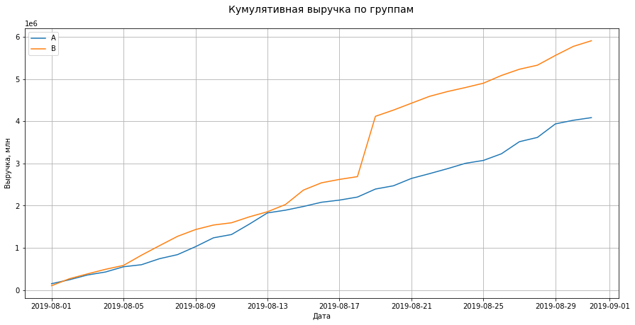

```python
plt.figure(figsize=(15,7))
plt.title('Кумулятивная выручка по группам\n', size = 14)
plt.xlabel('Дата')
plt.ylabel('Выручка, млн')
plt.plot(cumulative_revenue_a.date, cumulative_revenue_a.revenue, label='A')
plt.plot(cumulative_revenue_b.date, cumulative_revenue_b.revenue, label='B')
plt.grid()
plt.legend();
```

#### Вывод

- Выручка равномерно растет у обоих групп теста;
- Выручка группы B больше выручки A на протяжении почти всего теста;
- 18 августа происходит резкий рост выручки группы B, это означает или появление аномально дорогих заказов, или резкое увеличение числа заказов

### Кумулятивный средний чек по группам

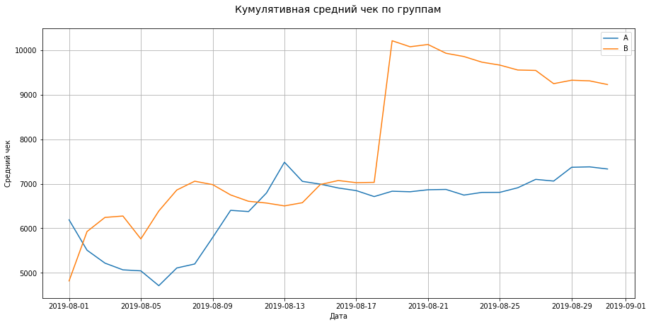

```python
plt.figure(figsize=(15,7))
plt.title('Кумулятивная средний чек по группам\n', size = 14)
plt.xlabel('Дата')
plt.ylabel('Средний чек')
plt.plot(cumulative_revenue_a.date, cumulative_revenue_a.revenue / cumulative_revenue_a.orders, label='A')
plt.plot(cumulative_revenue_b.date, cumulative_revenue_b.revenue / cumulative_revenue_b.orders, label='B')
plt.grid()
plt.legend();
```

#### Вывод

- Средний чек гораздо менее равномерен, чем выручка;
- Средний чек группы B почти всегда выше чем у группы A;
- 18 августа происходит резкий, с 7000 до 10000, скачок среднего чека у группы B, что означает аномально крупный заказ или заказы в этот день в данной группе

### Относительное изменение кумулятивного среднего чека группы B к группе A

Объединяем таблицы средних чеков A и B по дате методом merge()

```python
merged_cumulative_revenue = (cumulative_revenue_a
                            .merge(cumulative_revenue_b, left_on='date', right_on='date', how='left', suffixes=['_a', '_b']))
```

Строим график относительного изменения и добавляем 0-ую ось X(линия равенства средних чеков групп A и B)

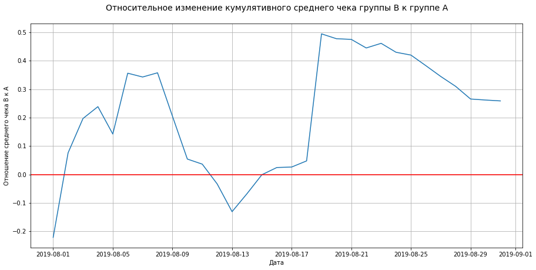

```python
plt.figure(figsize=(15,7))
plt.title('Относительное изменение кумулятивного среднего чека группы B к группе A\n', size = 14)
plt.xlabel('Дата')
plt.ylabel('Отношение среднего чека B к A')
plt.plot(merged_cumulative_revenue.date,
        (merged_cumulative_revenue.revenue_b/merged_cumulative_revenue.orders_b)/
        (merged_cumulative_revenue.revenue_a/merged_cumulative_revenue.orders_a)-1)
plt.axhline(y=0, color='red', linestyle='-')
plt.grid();
```

#### Вывод

- На протяжение всего эксперимента график похож кардиограмму - неравномерен и нелинеен;
- В нескольких точках (датах) есть резкие скачки - вверх и вниз, что говорит о больших заказах как в группе B так и в группе A

### Кумулятивная конверсия по группам

#### Подсчет кумулятивной конверсии в A и B

```python
cumulative_data['conversion'] = cumulative_data.orders/cumulative_data.visitors
cumulative_data_a = cumulative_data[cumulative_data.group=='A']
cumulative_data_b = cumulative_data[cumulative_data.group=='B']
```

#### Построение графика кумулятивной конверсии

Для правильного масштаба определим минимальное и максимальное значения конверсии

```python
cumulative_data.conversion.describe().loc[['min','max']]
```

```
min   0.03
max   0.04
Name: conversion, dtype: float64
```

Строим график

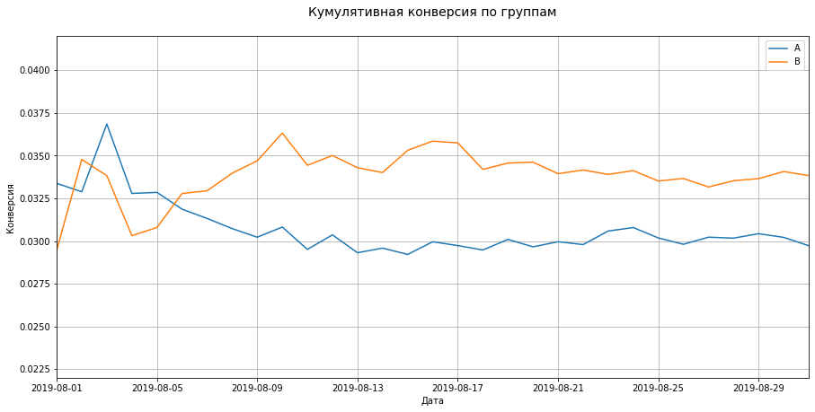

```python
plt.figure(figsize=(15,7))
plt.title('Кумулятивная конверсия по группам\n', size = 14)
plt.xlabel('Дата')
plt.ylabel('Конверсия')
plt.plot(cumulative_data_a.date, cumulative_data_a.conversion, label='A')
plt.plot(cumulative_data_b.date, cumulative_data_b.conversion, label='B')
plt.axis([cumulative_data.date.min(), cumulative_data.date.max(), 0.022, 0.042])
plt.grid()
plt.legend();
```

### Относительное изменение кумулятивной конверсии группы B к группе A

Объединяем таблицы кумулятивных конверсий A и B по дате методом merge()

```python
merged_сumulative_сonversions = (cumulative_data_a[['date','conversion']]
                                .merge(cumulative_data_b[['date','conversion']],
                                       left_on='date',
                                       right_on='date',
                                       how='left',
                                       suffixes=['_a', '_b'])
                                )
```

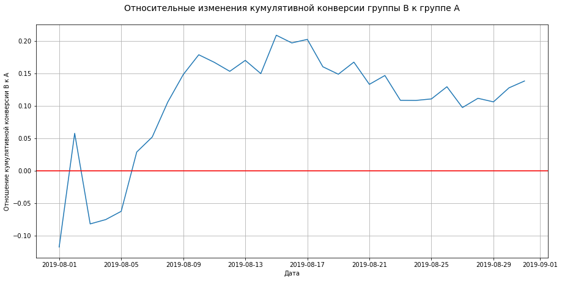

```python
plt.figure(figsize=(15,7))
plt.title('Относительные изменения кумулятивной конверсии группы B к группе A\n', size = 14)
plt.xlabel('Дата')
plt.ylabel('Отношение кумулятивной конверсии B к A')
plt.plot(merged_сumulative_сonversions.date,
        (merged_сumulative_сonversions.conversion_b/(merged_сumulative_сonversions.conversion_a) - 1));
plt.axhline(y=0, color='red', linestyle='-')
plt.grid();
```

#### Вывод

- Разница в кумулятивной конверсии почти всегда в пользу группы B
- 15 августа накопленная конверсия группы B на 20% больше группы A, 27 августа разница снижается до 10% и к концу эксперимента возрастает до 14%

### Количество заказов по пользователям

Сгруппируем таблицу orders по visitorid и посчитаем число заказов, а также удалим ненужные столбцы

```python
orders_by_users = (orders
                   .drop(['date', 'revenue', 'group'], axis=1)
                   .groupby('visitorid', as_index=False)
                   .agg({'transactionid':'nunique'})
                  )
orders_by_users.columns = ['user_id', 'orders']
orders_by_users.sort_values(by = 'orders', ascending = False)
```

|  | user_id | orders |
| --- | --- | --- |
| 1023 | 4256040402 | 11 |
| 591 | 2458001652 | 11 |
| 569 | 2378935119 | 9 |
| 487 | 2038680547 | 8 |
| 44 | 199603092 | 5 |
| ... | ... | ... |
| 359 | 1484903144 | 1 |
| 360 | 1485964287 | 1 |
| 361 | 1494664757 | 1 |
| 362 | 1495112755 | 1 |
| 1030 | 4283872382 | 1 |

1031 rows × 2 columns

Построим точечную диаграмму количества заказов на одного пользователя

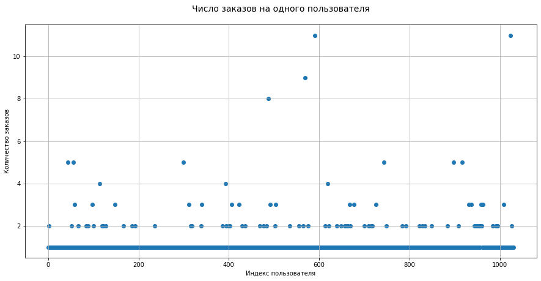

```python
x_values = pd.Series(range(0,len(orders_by_users)))
plt.figure(figsize=(15,7))
plt.scatter(x_values, orders_by_users.orders)
plt.title('Число заказов на одного пользователя\n', size = 14)
plt.xlabel('Индекс пользователя')
plt.ylabel('Количество заказов')
plt.grid();
```

#### Вывод

- Подавляющее большинство пользователей совершило 1 или 2 заказа;
- Пользователи сделавшие 3 и более покупок, скорее всего являются "аномалиями"

### Подсчет 95-го и 99-го перцентиля количества заказов на пользователя

```python
np.percentile(orders_by_users.orders, [95, 99])
```

```
array([2., 4.])
```

#### Вывод

- Только 5% пользователей сделало более 2-х заказов (95% совершило 1 или 2 заказа)
- Только 1% пользователей сделал более 4-х заказов (99% совершило от 1 до 4-х заказов)
- "Нормальными" данными, будем считать, входящие в 95-ый перцентиль; все кто сделал больше 2-х заказов - аномалии

### Стоимость заказов

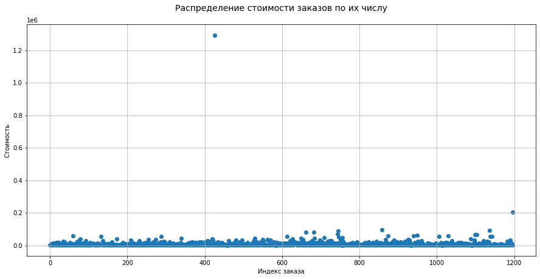

```python
x_values = pd.Series(range(0,len(orders.revenue)))
plt.figure(figsize=(15,7))
plt.scatter(x_values, orders.revenue)
plt.title('Распределение стоимости заказов по их числу\n', size = 14)
plt.xlabel('Индекс заказа')
plt.ylabel('Стоимость')
plt.grid();
```

#### Вывод

- Есть два заказа-выброса: на 1.3 млн и 200 тыс.
- Остальные заказы не превышают 100 тыс
- Большинство заказов не более 10 тыс

### Подсчет 95-го и 99-го перцентиля стоимости заказов

```python
np.percentile(orders.revenue, [95, 99])
```

```
array([28000. , 58233.2])
```

#### Вывод

- 5% пользователей сделало покупку дороже 28000
- 1% пользователей сделал покупку дороже 58233.2
- "Нормальными" данными, будем считать, входящие в 95-ый перцентиль; все кто сделал покупку дороже 28000 - аномалии

### Подсчет статистической значимости различий в конверсии между группами по "сырым" данным

#### Соберем "сырые" данные в одну таблицу

Число пользователей в день для каждой группы

```python
visitors_a_daily = visitors[visitors.group == 'A'][['date', 'visitors']]
visitors_a_daily.columns = ['date', 'visitors_per_date_a']

visitors_b_daily = visitors[visitors.group == 'B'][['date', 'visitors']]
visitors_b_daily.columns = ['date', 'visitors_per_date_b']
```

Число кумулятивных пользователей в день для каждой группы

```python
visitors_a_cummulative = (visitors_a_daily
                         .apply(lambda x: visitors_a_daily[visitors_a_daily.date <= x.date]
                         .agg({'date': 'max', 'visitors_per_date_a': 'sum'}), axis=1,)
                         )
visitors_a_cummulative.columns = ['date', 'visitors_cummulative_a']

visitors_b_cummulative = (visitors_b_daily
                        .apply(lambda x: visitors_b_daily[visitors_b_daily.date <= x.date]
                        .agg({'date': 'max', 'visitors_per_date_b': 'sum'}), axis=1,)
                         )
visitors_b_cummulative.columns = ['date', 'visitors_cummulative_b']
```

Число заказов и выручка за день для каждой группы

```python
orders_a_daily = (orders[orders.group=='A'][['date', 'transactionid', 'revenue']]
                 .groupby('date', as_index=False)
                 .agg({'transactionid':'nunique', 'revenue':'sum'})
                 )
orders_a_daily.columns = ['date', 'orders_per_date_a', 'revenue_per_date_a']

orders_b_daily = (orders[orders.group=='B'][['date', 'transactionid', 'revenue']]
                 .groupby('date', as_index=False)
                 .agg({'transactionid':'nunique', 'revenue':'sum'})
                 )
orders_b_daily.columns = ['date', 'orders_per_date_b', 'revenue_per_date_b']
```

Кумулятивное число заказов и выручки за день для каждой группы

```python
orders_a_cummulative = (orders_a_daily
                       .apply(lambda x: orders_a_daily[orders_a_daily.date <= x.date]
                       .agg({'date':'max', 'orders_per_date_a':'sum', 'revenue_per_date_a':'sum'}), axis=1)
                       )
orders_a_cummulative.columns = ['date', 'orders_cummulative_a', 'revenue_cummulative_a']

orders_b_cummulative = (orders_a_daily
                       .apply(lambda x: orders_b_daily[orders_b_daily.date <= x.date]
                       .agg({'date':'max', 'orders_per_date_b':'sum', 'revenue_per_date_b':'sum'}), axis=1)
                       )
orders_b_cummulative.columns = ['date', 'orders_cummulative_b', 'revenue_cummulative_b']
```

Собираем все данные в одну таблицу методом merge()

```python
data = (orders_a_daily
        .merge(orders_b_daily, left_on='date', right_on='date', how='left')
        .merge(orders_a_cummulative, left_on='date', right_on='date', how='left')
        .merge(orders_b_cummulative, left_on='date', right_on='date', how='left')
        .merge(visitors_a_daily, left_on='date', right_on='date', how='left')
        .merge(visitors_b_daily, left_on='date', right_on='date', how='left')
        .merge(visitors_a_cummulative, left_on='date', right_on='date', how='left')
        .merge(visitors_b_cummulative, left_on='date', right_on='date', how='left')
       )
data.head()
```

|  | date | orders_per_date_a | revenue_per_date_a | orders_per_date_b | revenue_per_date_b | orders_cummulative_a | revenue_cummulative_a | orders_cummulative_b | revenue_cummulative_b | visitors_per_date_a | visitors_per_date_b | visitors_cummulative_a | visitors_cummulative_b |
| --- | --- | --- | --- | --- | --- | --- | --- | --- | --- | --- | --- | --- | --- |
| 0 | 2019-08-01 | 24 | 148579 | 21 | 101217 | 24 | 148579 | 21 | 101217 | 719 | 713 | 719 | 713 |
| 1 | 2019-08-02 | 20 | 93822 | 24 | 165531 | 44 | 242401 | 45 | 266748 | 619 | 581 | 1338 | 1294 |
| 2 | 2019-08-03 | 24 | 112473 | 16 | 114248 | 68 | 354874 | 61 | 380996 | 507 | 509 | 1845 | 1803 |
| 3 | 2019-08-04 | 16 | 70825 | 17 | 108571 | 84 | 425699 | 78 | 489567 | 717 | 770 | 2562 | 2573 |
| 4 | 2019-08-05 | 25 | 124218 | 23 | 92428 | 109 | 549917 | 101 | 581995 | 756 | 707 | 3318 | 3280 |

#### Гипотезы

H₀ - статистически значимых различий в конверсии между группами нет  
H₁ - статистически значимые различия в конверсии между группами есть

Подсчитаем число заказов каждого пользователя по группам

```python
orders_by_users_a = (orders[orders.group=='A']
                     .groupby('visitorid', as_index=False)
                     .agg({'transactionid':'nunique'})
                    )
orders_by_users_a.columns = ['visitorid', 'orders']

orders_by_users_b = (orders[orders.group=='B']
                     .groupby('visitorid', as_index=False)
                     .agg({'transactionid':'nunique'})
                    )
orders_by_users_b.columns = ['visitorid', 'orders']
```

Для проверки критерием Манна-Уитни, создадим две выборки, в которых пользователям из разных групп будет соответствовать количество заказов, у тех кто ничего не покупал число заказов = 0

```python
sample_a = pd.concat([orders_by_users_a.orders,
                      pd.Series(0, index=np.arange
                                         (data.visitors_per_date_a.sum() - len(orders_by_users_a.orders)),
                      name='orders')],axis=0)

sample_b = pd.concat([orders_by_users_b.orders,
                      pd.Series(0, index=np.arange
                                         (data.visitors_per_date_b.sum() - len(orders_by_users_b.orders)),
                      name='orders')],axis=0)
```

Проверим гипотезы

```python
alpha = .05
results = stats.mannwhitneyu(sample_a, sample_b)
print("p-значение: {0:.4f}".format(results.pvalue))
if (results.pvalue < alpha):
    print("Отвергаем нулевую гипотезу: разница статистически значима")
else:
    print("Не получилось отвергнуть нулевую гипотезу, вывод о различии сделать нельзя")
print("Конверсия группы B лучше чем конверсия группы A на: {0:.1%}".format(sample_b.mean()/sample_a.mean()-1))
```

```
p-значение: 0.0168
Отвергаем нулевую гипотезу: разница статистически значима
Конверсия группы B лучше чем конверсия группы A на: 13.8%
```

#### Вывод

- Нулевая гипотеза отвергнута, разница статистически значима - конверсии в группах A и B различны;
- Конверсия в группе B на 13,8% лучше, чем в группе A

### Различия в среднем чеке заказа между группами по "сырым" данным

Формулируем гипотезы:  
H₀ - статистически значимых различий в среднем чеке между группами нет  
H₁ - статистически значимые различия в среднем чеке между группами есть

```python
alpha = .05
results = stats.mannwhitneyu(orders[orders.group=='A'].revenue, orders[orders.group=='B'].revenue)
print("p-значение: {0:.4f}".format(results.pvalue))
if (results.pvalue < alpha):
    print("Отвергаем нулевую гипотезу: разница статистически значима")
else:
    print("Не получилось отвергнуть нулевую гипотезу, вывод о различии сделать нельзя")
print("Средний чек группы B больше чем средний чек группы A на: {0:.1%}"
      .format(orders[orders.group=='B'].revenue.mean()/orders[orders.group=='A'].revenue.mean()-1))
```

```
p-значение: 0.7293
Не получилось отвергнуть нулевую гипотезу, вывод о различии сделать нельзя
Средний чек группы B больше чем средний чек группы A на: 25.9%
```

#### Вывод

- Нулевую гипотезу отвергнуть не удалось - статистически значимых различий между группами в среднем чеке нет;
- Средний чек группы B больше среднего чека в группе A на 26%, очевидно такая разница получилась из-за аномально больших единичных заказов ('выбросов')

### Статистическая значимость различий в конверсии между группами по "очищенным" данным

#### "Очищаем" данные

Будем считать "очищенными" данные, которые попадают в 95-ый перцентиль, фильтруем пользователей с числом заказов больше 2-х или единичной покупкой больше 28000

```python
users_with_many_orders = pd.concat(
                                  [orders_by_users_a[orders_by_users_a.orders > np.percentile(orders_by_users.orders, 95)].visitorid,
                                   orders_by_users_b[orders_by_users_b.orders > np.percentile(orders_by_users.orders, 95)].visitorid,],
                                   axis=0,
                                  )
```

```python
users_with_expensive_orders = orders[orders.revenue > np.percentile(orders.revenue, 95)].visitorid
```

```python
abnormal_users = (pd
                .concat([users_with_many_orders, users_with_expensive_orders], axis=0)
                .drop_duplicates()
                .sort_values()
                )
```

```python
print("Число 'отфильтрованных' пользователей =", abnormal_users.count())
```

```
Число 'отфильтрованных' пользователей = 74
```

Создадим два "отфильтрованных" массива о заказах для групп А и В

```python
sample_a_filtered = pd.concat(
                             [orders_by_users_a[np.logical_not(orders_by_users_a.visitorid.isin(abnormal_users))].orders,
                              pd.Series(0, index=np.arange(data.visitors_per_date_a.sum() - len(orders_by_users_a.orders)),
                              name='orders',),], axis=0,)

sample_b_filtered = pd.concat(
                             [orders_by_users_b[np.logical_not(orders_by_users_b.visitorid.isin(abnormal_users))].orders,
                              pd.Series(0, index=np.arange(data.visitors_per_date_b.sum() - len(orders_by_users_b.orders)),
                              name='orders',),], axis=0,)
```

#### Гипотеза о статистической значимости различий в конверсии между группами на "очищенных" данных

H₀ - статистически значимых различий в конверсии между группами нет  
H₁ - статистически значимые различия в конверсии между группами есть

```python
alpha = .05
results = stats.mannwhitneyu(sample_a_filtered, sample_b_filtered)
print("p-значение: {0:.4f}".format(results.pvalue))
if (results.pvalue < alpha):
    print("Отвергаем нулевую гипотезу: разница статистически значима")
else:
    print("Не получилось отвергнуть нулевую гипотезу, вывод о различии сделать нельзя")
print("Конверсия группы B лучше чем конверсия группы A на:: {0:.1%}".format(sample_b_filtered.mean()/sample_a_filtered.mean()-1))
```

```
p-значение: 0.0130
Отвергаем нулевую гипотезу: разница статистически значима
Конверсия группы B лучше чем конверсия группы A на:: 17.3%
```

#### Вывод

- Нулевая гипотеза отвергнута, разница статистически значима - конверсии на "очищенных" данных в группах A и B различны;
- Конверсия в группе B на 17.3% лучше, чем в группе A

### Различия в среднем чеке заказа между группами на "очищенных" данных

Формулируем гипотезы:  
H₀ - статистически значимых различий в среднем чеке между группами нет  
H₁ - статистически значимые различия в среднем чеке между группами есть

```python
alpha = .05
results = stats.mannwhitneyu(
          orders[np.logical_and(orders.group == 'A', np.logical_not(orders.visitorid.isin(abnormal_users)),)].revenue,
          orders[np.logical_and(orders.group == 'B', np.logical_not(orders.visitorid.isin(abnormal_users)),)].revenue
                            )
print("p-значение: {0:.4f}".format(results.pvalue))
if (results.pvalue < alpha):
    print("Отвергаем нулевую гипотезу: разница статистически значима")
else:
    print("Не получилось отвергнуть нулевую гипотезу, вывод о различии сделать нельзя")
print("Средний чек группы B больше чем средний чек группы A на:: {0:.1%}"
      .format(orders[np.logical_and(orders.group=='B',np.logical_not(orders.visitorid.isin(abnormal_users)))].revenue.mean()/
              orders[np.logical_and(orders.group=='A',np.logical_not(orders.visitorid.isin(abnormal_users)))].revenue.mean() - 1))
```

```
p-значение: 0.7385
Не получилось отвергнуть нулевую гипотезу, вывод о различии сделать нельзя
Средний чек группы B больше чем средний чек группы A на:: -2.0%
```

#### Вывод

- Нулевую гипотезу отвергнуть не удалось - на "очищенных" данных статистически значимых различий между группами в среднем чеке нет;
- Средний чек группы A оказался даже больше среднего чека группы B на 2%, это говорит о том, что "выбросы" отфильтрованы корректно

### Вывод

- Разница в конверсии между группами на "сырых" данных составляет 13.8%, на "очищенных" 17.3%
- И на "сырых" и на "очищенных" данных тест Манна—Уитни показал наличие статистически значимых различий: группа B конвертируется лучше чем группа A
- Разница в средних чеках между группами на "сырых" данных составляет 25.9%, на "очищенных" 2%, причем на "сырых" средний чек больше у группы B, а на "очищенных" данных средний чек выше в группе A
- И на "сырых"(несмотря на 26%-ую разницу) и на "очищенных" данных тест Манна—Уитни значимых статистических различий не нашел: средние чеки в группах A и B не различаются

## Решение по результатам A/B-теста

- Конверсия в группе B выше чем в группе A более чем на 10% и на полных и на отфильтрованных от "шопоголиков" данных
- Статистических различий в среднем чеке, если далее тест продолжить "до бесконечности", не будет
- Поскольку конверсия один из важнейших маркетинговых параметров, то и с одинаковыми средними чеками группу B стоит признать победительницей, а A/B-тест успешно завершенным